# pseudogenes

**Libraries**

```r
library(rtracklayer)
library(GenomicFeatures)
library(txdbmaker)
library(Biostrings)
library(BSgenome)
library(BSgenomeForge)
library(dplyr)
library(GenomicRanges)
library(GenomeInfoDb)
library(Biostrings)
library(BSgenome)
library(ggplot2)
library(scales)
library(ggpointdensity)
```

**Loading data - Loading seqs + filtering**

```r
library(BSgenome.Dlaeve.NCBI.dlgm)
genome <- BSgenome.Dlaeve.NCBI.dlgm
```

```r
print(class(genome))
```

## [1] “BSgenome”

## attr(,“package”)

## [1] “BSgenome”

```r
length(genome)
```

## [1] 3497

```r
genome
```

## | BSgenome object

## | - organism: Deroceras laeve

## | - provider: NCBI

## | - genome: dl_gm

## | - 3497 sequence(s):

## | chr1 chr2 chr3 chr4

## | chr5 chr6 chr7 chr8

## | chr9 chr10 chr11 chr12

## | chr13 chr14 chr15 chr16

## | chr17 chr18 chr19 chr20

## | … … … …

## | HiC_scaffold_3481 HiC_scaffold_3482 HiC_scaffold_3483 HiC_scaffold_3484

## | HiC_scaffold_3485 HiC_scaffold_3486 HiC_scaffold_3487 HiC_scaffold_3488

## | HiC_scaffold_3489 HiC_scaffold_3490 HiC_scaffold_3491 HiC_scaffold_3492

## | HiC_scaffold_3493 HiC_scaffold_3494 HiC_scaffold_3495 HiC_scaffold_3496

## | HiC_scaffold_3497

## |

## | Tips: call ‘seqnames()’ on the object to get all the sequence names, call ‘seqinfo()’ to

## | get the full sequence info, use the ‘$’ or ‘[[’ operator to access a given sequence, see

## | ‘?BSgenome’ for more information.

```r
# names present in your BSgenome
nm  <- seqnames(genome)

# choose only proper chromosomes (e.g. chr1..chr31), ignore the HiC_scaffold zoo
keep <- intersect(paste0("chr", 1:31), nm)          # safe even if some are missing

# grab them quickly as a DNAStringSet (lightweight, fast)
genome_chr <- getSeq(genome, keep)

# sanity check
length(genome_chr); head(names(genome_chr))
```

## [1] 31## [1] “chr1” “chr2” “chr3” “chr4” “chr5” “chr6”

```r
transcriptome <- import("C:/Users/rafae/OneDrive/Desktop/Genomics/derLaeGenome_namesDlasi_v2.fasta.functional_note.pseudo_label.gff")
```

```r
transcriptome
```

## GRanges object with 1756563 ranges and 17 metadata columns:

## seqnames ranges strand | source type score

## |

## [1] HiC_scaffold_1005 6207-7268 - | EviAnn gene NA

## [2] HiC_scaffold_1005 6207-7268 - | EviAnn mRNA NA

## [3] HiC_scaffold_1005 6207-7268 - | EviAnn exon NA

## [4] HiC_scaffold_1005 6207-7268 - | EviAnn CDS NA

## [5] HiC_scaffold_1005 7529-9631 + | EviAnn gene NA

## … … … … . … … …

## [1756559] chr9 73153203-73153305 - | EviAnn CDS NA

## [1756560] chr9 73155022-73155165 - | EviAnn CDS NA

## [1756561] chr9 73157349-73157465 - | EviAnn CDS NA

## [1756562] chr9 73161856-73161986 - | EviAnn CDS NA

## [1756563] chr9 73179656-73179782 - | EviAnn CDS NA

## phase ID geneID gene_biotype

## [1] LOC_00034091 LOC_00034091 protein_coding

## [2] LOC_00034091-mRNA-1 LOC_00034091 protein_coding

## [3]

## [4] 0

## [5] LOC_00034092 LOC_00034092 protein_coding

## … … … … …

## [1756559] 0

## [1756560] 0

## [1756561] 0

… [43 líneas truncadas]

```r
table(transcriptome$gene_biotype)
```

## lncRNA processed_pseudogene protein_coding

## 1832 871 120268

```r
pseudogenes <- transcriptome[transcriptome$type == "gene" & transcriptome$gene_biotype == "processed_pseudogene"]
length(pseudogenes)
```

## [1] 432

```r
# keep only chromosomes present in genome_chr, drop scaffolds safely
pseudogenes <- keepSeqlevels(pseudogenes, seqlevels(genome_chr), pruning.mode = "coarse")

# now set seqinfo to match your chromosome-only genome
seqinfo(pseudogenes) <- seqinfo(genome_chr)
```

```r
geneinfo <- mcols(pseudogenes)[c("geneID","Note")]
geneinfo
```

## DataFrame with 420 rows and 2 columns

## geneID Note

## 1 LOC_00005679 function unknown

## 2 LOC_00005727 function unknown

## 3 LOC_00005745 function unknown

## 4 LOC_00005857 function unknown

## 5 LOC_00006089 function unknown

## … … …

## 416 LOC_00000844 function unknown

## 417 LOC_00000852 function unknown

## 418 LOC_00000878 function unknown

## 419 LOC_00000917 function unknown

## 420 LOC_00000930 function unknown

```r
pseudogenes <- trim(pseudogenes)
proteinGenes_seqs <- getSeq(genome_chr, pseudogenes)
```

*Body*

```r
length(proteinGenes_seqs)
```

## [1] 420

```r
proteinGenes_seqs
```

## DNAStringSet object of length 420:

## width seq

## [1] 3281 CCACTTTATTGCACATTATATAAACACGATTTGTTTAG…CCCAGTGTATGAAGTGAAACCTGCAACCATTTTCAAA

## [2] 189 ATGCGGCGACTCGCTCTCCTAGCGGCGTTTGCAGAGTT…AAGACAGTGTGCCAGGAAGGCAGCGGTAGTCGAATGA

## [3] 393 ATGGATTACACCCAAAAAACATCCTCCATTATACTTAA…TGACAAGCTGAGAGAAGAAACAAAACAAAATATATAA

## [4] 387 ATGGAAAGAAAACTGGTCGCTTTTGAAAACAAATGCCT…TGCCCTATGCGCCAAACTAGGCACCAGAGGAATATGA

## [5] 543 ATGACAAGAATTGCTCTAGCAGCTAATGCCTTCAACAG…TGCCCTATGCGCCAAACTAGGCACCAGAGGAATATGA

## … … …

## [416] 564 ATGAAGATCAGCACGACCAGAACAGAAGTCATGTCAAT…GTGCCCTAGAGCAAGAGGCAGGCCCAGAGTGCGATAG

## [417] 456 ATGTTTAAAATGGCTAAGACTACTGATGACAATGAAAG…TTGGGAAAAATTGATGTTTGCCATGCCAGATGTTTGA

## [418] 486 ATGAAGACTATACTGTCTAACAGAAATATTCTTTTCCA…CATGATCGCCAATGCTTTCAGGCAGGGCACAGGATGA

## [419] 632 AAATAGCTTTGATCTCACATAGTCGTACAACATTCCAT…AGAACAGGAAGAGCTCAACATTATGAACCAGTAAACT

## [420] 324 ATGCTAAAAGTGCCATGGACAGATAAAATAACTAATGA…CATGACCGCCAATGTCTATCGACAAGGCACTTCTTGA

**Counting**

```r
letterFrequency_all <- letterFrequency(proteinGenes_seqs, c("A", "T", "C", "G")) %>% as.data.frame %>% tibble()
letterFrequency_all
```

| A | T | C | G |
| --- | --- | --- | --- |
| 1199 | 986 | 488 | 608 |
| 41 | 38 | 51 | 59 |
| 167 | 87 | 76 | 63 |
| 176 | 56 | 75 | 80 |
| 237 | 91 | 108 | 107 |
| 927 | 838 | 391 | 495 |
| 184 | 105 | 77 | 120 |
| 167 | 85 | 108 | 93 |
| 137 | 129 | 88 | 105 |
| 220 | 154 | 123 | 172 |

[output cut: 410 more lines]

```r
C_all <- letterFrequency_all[3]
G_all <- letterFrequency_all[4]
Width_all <- width(proteinGenes_seqs)
CG_all <- dinucleotideFrequency(proteinGenes_seqs)[,"CG"]
```

```r
OE_all = (CG_all*Width_all)/(C_all*G_all)
colnames(OE_all) <- c("OEindex")
OE_all
```

| OEindex |
| --- |
| 0.2653958 |
| 0.9421735 |
| 0.4104010 |
| 0.8385000 |
| 0.7518172 |
| 0.3424268 |
| 0.5259740 |
| 0.5412186 |
| 0.5464286 |
| 0.6008225 |

[output cut: 410 more lines]

```r
cgContent_all = (C_all+G_all)/Width_all
colnames(cgContent_all) <- c("CGpercentage")
cgContent_all
```

| CGpercentage |
| --- |
| 0.3340445 |
| 0.5820106 |
| 0.3536896 |
| 0.4005168 |
| 0.3959484 |
| 0.3342135 |
| 0.4053498 |
| 0.4437086 |
| 0.4204793 |
| 0.4409567 |

[output cut: 410 more lines]

```r
df <- cbind(OE_all,cgContent_all)
df
```

| OEindex | CGpercentage |
| --- | --- |
| 0.2653958 | 0.3340445 |
| 0.9421735 | 0.5820106 |
| 0.4104010 | 0.3536896 |
| 0.8385000 | 0.4005168 |
| 0.7518172 | 0.3959484 |
| 0.3424268 | 0.3342135 |
| 0.5259740 | 0.4053498 |
| 0.5412186 | 0.4437086 |
| 0.5464286 | 0.4204793 |
| 0.6008225 | 0.4409567 |

[output cut: 410 more lines]

**Graphs**

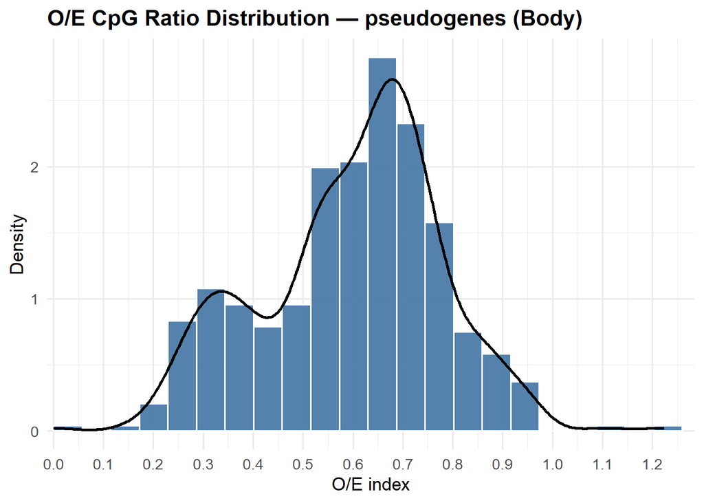

```r
x <- OE_all$OEindex
x <- x[is.finite(x)]
bw <- 2 * IQR(x) / length(x)^(1/3)
if (!is.finite(bw) || bw <= 0) bw <- diff(range(x)) / 80
xmin <- floor(min(x) * 10) / 10
xmax <- ceiling(max(x) * 10) / 10

ggplot(OE_all, aes(x = OEindex)) +
  geom_histogram(aes(y = after_stat(density)),
                 binwidth = bw, boundary = 0, closed = "left",
                 fill = "#4C7BA8", color = "white", alpha = 0.95) +
  geom_density(linewidth = 0.9, color = "black", alpha = 0.6) +
  scale_x_continuous(
    breaks = seq(xmin, xmax, by = 0.1),
    minor_breaks = seq(xmin, xmax, by = 0.05),
    labels = number_format(accuracy = 0.1),
    expand = expansion(mult = c(0.01, 0.02))
  ) +
  labs(
    title = "O/E CpG Ratio Distribution — pseudogenes (Body)",
    x = "O/E index",
    y = "Density"
  ) +
  theme_minimal(base_size = 13) +
  theme(
    panel.grid.minor = element_line(),
    plot.title = element_text(face = "bold")
  )
```

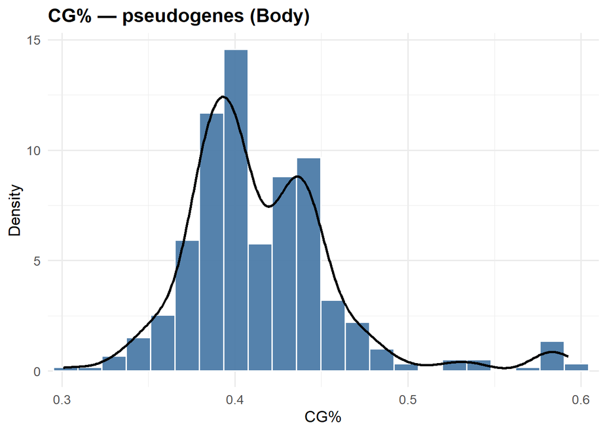

```r
x <- cgContent_all$CGpercentage
x <- x[is.finite(x)]
bw <- 2 * IQR(x) / length(x)^(1/3)
if (!is.finite(bw) || bw <= 0) bw <- diff(range(x)) / 80
xmin <- floor(min(x) * 10) / 10
xmax <- ceiling(max(x) * 10) / 10

ggplot(cgContent_all, aes(x = CGpercentage)) +
  geom_histogram(aes(y = after_stat(density)),
                 binwidth = bw, boundary = 0, closed = "left",
                 fill = "#4C7BA8", color = "white", alpha = 0.95) +
  geom_density(linewidth = 0.9, color = "black", alpha = 0.6) +
  scale_x_continuous(
    breaks = seq(xmin, xmax, by = 0.1),
    minor_breaks = seq(xmin, xmax, by = 0.05),
    labels = number_format(accuracy = 0.1),
    expand = expansion(mult = c(0.01, 0.02))
  ) +
  labs(
    title = "CG% — pseudogenes (Body)",
    x = "CG%",
    y = "Density"
  ) +
  theme_minimal(base_size = 13) +
  theme(
    panel.grid.minor = element_line(),
    plot.title = element_text(face = "bold")
  )
```

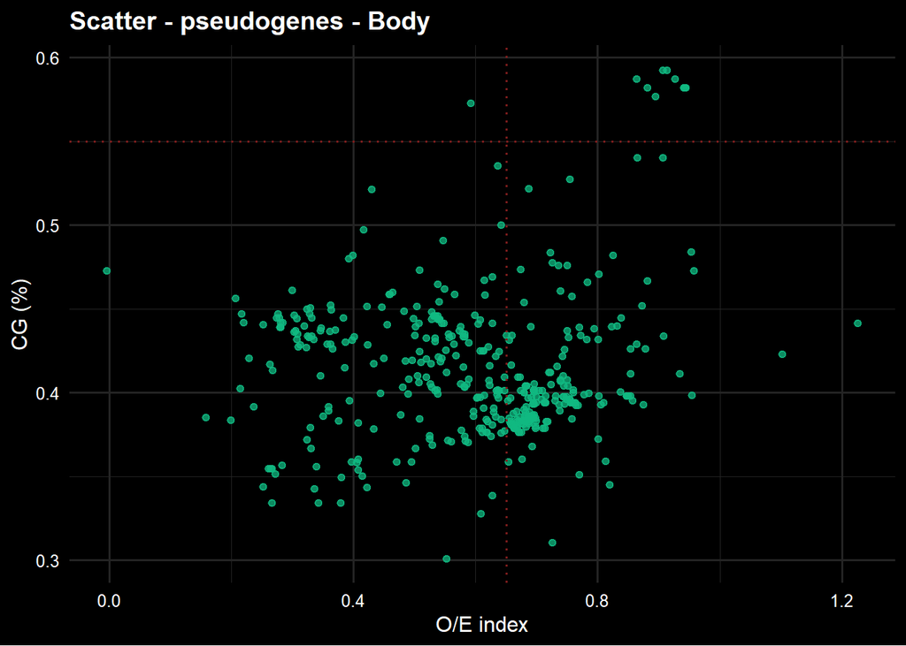

```r
plot_nice_dark <- function(d, x="OEindex", y="CGpercentage",
                           xthr=.65, ythr=.55, title="Scatter - pseudogenes - Body",
                           point_col="#10b981", thr_col="#7f1d1d"){   # green, violet
  dd <- data.frame(x=as.numeric(d[[x]]), y=as.numeric(d[[y]]))
  dd <- dd[is.finite(dd$x) & is.finite(dd$y), ]
  ggplot(dd, aes(x, y)) +
    geom_point(color=point_col, alpha=.75, size=1.6,
               position=position_jitter(width=.004, height=0)) +
    geom_vline(xintercept=xthr, color=thr_col, linewidth=.6, linetype="dotted") +
    geom_hline(yintercept=ythr, color=thr_col, linewidth=.6, linetype="dotted") +
    labs(title=title, x="O/E index", y="CG (%)") +
    theme_minimal(base_size=12) +
    theme(
      plot.background  = element_rect(fill="black", color=NA),
      panel.background = element_rect(fill="black", color=NA),
      panel.grid       = element_line(color="#242424"),
      axis.text        = element_text(color="white"),
      axis.title       = element_text(color="white"),
      plot.title       = element_text(color="white", face="bold")
    )
}

# use:
plot_nice_dark(df)
```

**PCA**

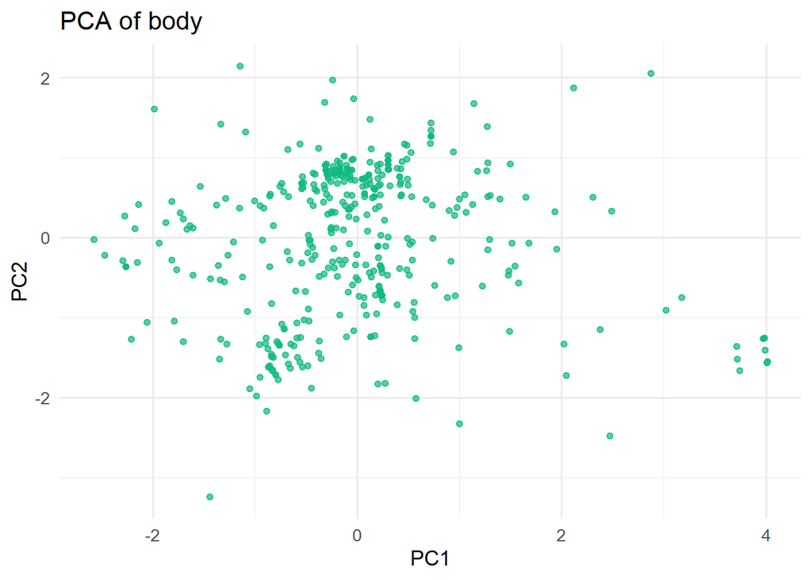

```r
# 1) Clean: keep numeric cols, drop NA/Inf rows, drop zero-variance cols
X <- df[, sapply(df, is.numeric), drop = FALSE]
X <- X[Reduce(`&`, lapply(X, is.finite)), , drop = FALSE]
X <- X[, sapply(X, function(z) sd(z) > 0), drop = FALSE]

# 2) PCA
pca <- prcomp(X, center = TRUE, scale. = TRUE)
pc  <- as.data.frame(pca$x[, 1:2, drop = FALSE])

ggplot(pc, aes(PC1, PC2)) +
  geom_point(alpha = .7, size = 1.6, color = "#10b981") +
  theme_minimal(base_size = 13) +
  labs(title = "PCA of body", x = "PC1", y = "PC2")
```

```r
summary(pca)
```

## Importance of components:

## PC1 PC2

## Standard deviation 1.0648 0.9307

## Proportion of Variance 0.5669 0.4331

## Cumulative Proportion 0.5669 1.0000

```r
cor(df$OEindex, df$CGpercentage)
```

## [1] 0.1337212

**K-Means**

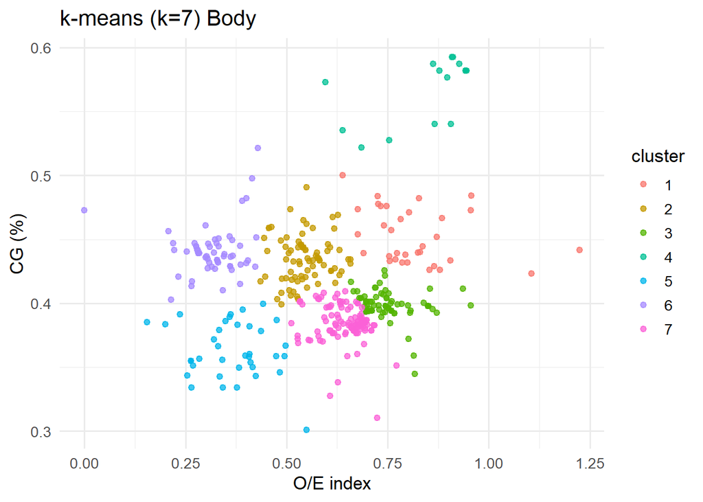

```r
# clean once; keep the mask so we can put labels back correctly
X <- df[, c("OEindex","CGpercentage")]
m <- is.finite(X$OEindex) & is.finite(X$CGpercentage)
Xc <- scale(X[m, , drop=FALSE])

set.seed(42)
k  <- 7
km <- kmeans(Xc, centers=k, nstart=50)

df$cluster <- NA_integer_
df$cluster[m] <- km$cluster
df$cluster <- factor(df$cluster)

ggplot(df[!is.na(df$cluster),], aes(OEindex, CGpercentage, color=cluster)) +
  geom_point(alpha=.75, size=1.7) +
  theme_minimal(base_size=13) +
  labs(title=sprintf("k-means (k=%d) Body", k),
       x="O/E index", y="CG (%)")
```

```r
#Add names
df <- cbind(geneinfo, df)
df
```

## DataFrame with 420 rows and 5 columns

## geneID Note OEindex CGpercentage cluster

## 1 LOC_00005679 function unknown 0.265396 0.334044 5

## 2 LOC_00005727 function unknown 0.942173 0.582011 4

## 3 LOC_00005745 function unknown 0.410401 0.353690 5

## 4 LOC_00005857 function unknown 0.838500 0.400517 3

## 5 LOC_00006089 function unknown 0.751817 0.395948 3

## … … … … … …

## 416 LOC_00000844 function unknown 0.552168 0.425532 2

## 417 LOC_00000852 function unknown 0.652427 0.434211 2

## 418 LOC_00000878 function unknown 0.532544 0.401235 7

## 419 LOC_00000917 function unknown 0.404609 0.433544 6

## 420 LOC_00000930 function unknown 0.716462 0.398148 3

```r
#Body list with cgi arquitecture
df_filtered_cgi_body <- dplyr::filter(as.data.frame(df), OEindex >= 0.65, CGpercentage >= .55)
df_filtered_cgi_body
```

| geneID | Note | OEindex | CGpercentage | cluster |
| --- | --- | --- | --- | --- |
| LOC_00005727 |  | 0.9421735 | 0.5820106 | 4 |
| LOC_00012267 |  | 0.9086538 | 0.5925926 | 4 |
| LOC_00020955 |  | 0.9421735 | 0.5820106 | 4 |
| LOC_00013372 |  | 0.9112825 | 0.5925926 | 4 |
| LOC_00011523 |  | 0.8969492 | 0.5767196 | 4 |
| LOC_00017784 |  | 0.9450000 | 0.5820106 | 4 |
| LOC_00003696 |  | 0.8773210 | 0.5820106 | 4 |
| LOC_00000237 |  | 0.9421735 | 0.5820106 | 4 |
| LOC_00000361 |  | 0.9264706 | 0.5873016 | 4 |
| LOC_00000441 |  | 0.8624511 | 0.5873016 | 4 |

```r
C_all_sum <- sum(C_all)
G_all_sum <- sum(G_all)
Width_all_sum <- sum(width(proteinGenes_seqs))
CG_all_sum <- sum(CG_all)
```

```r
C_all_sum <- as.numeric(C_all_sum)
G_all_sum  <- as.numeric(G_all_sum)
Width_all_sum <- as.numeric(Width_all_sum)
CG_all_sum <- as.numeric(CG_all_sum)
```

```r
#CG% sum - Body
cgContent_all_sum <- (C_all_sum+G_all_sum)/Width_all_sum
cgContent_all_sum
```

## [1] 0.399377

```r
#OE Index sum - Body
OE_all_sum <- (CG_all_sum*Width_all_sum)/(C_all_sum*G_all_sum)
OE_all_sum
```

## [1] 0.5669183

```r
#Body sums totals
C_all_sum
```

## [1] 96886

```r
G_all_sum
```

## [1] 105442

```r
Width_all_sum
```

## [1] 506609

```r
CG_all_sum
```

## [1] 11432

```r
cgContent_all_sum
```

## [1] 0.399377

```r
OE_all_sum
```

## [1] 0.5669183

```r
#Porcentaje/Ratio de GCs en el cuerpo segun el span del cuerpo
CG_all_sum/Width_all_sum
```

## [1] 0.02256573

```r
#Porcentaje/Ratio de GC del cuerpo en comparacion al genoma
genomeCG_totalcount = 45535149
CG_all_sum/45535149
```

## [1] 0.0002510588

*PROMOTORES*

```r
promotores_500bp <- promoters(pseudogenes, upstream = 2000, downstream = 0)


seqlevelsStyle(promotores_500bp) <- seqlevelsStyle(genome)
promotores_500bp <- keepSeqlevels(
  promotores_500bp,
  intersect(seqlevels(promotores_500bp), seqlevels(genome)),
  pruning.mode = "coarse"
)
seqinfo(promotores_500bp) <- seqinfo(genome)[seqlevels(promotores_500bp)]
promotores_500bp <- trim(promotores_500bp)

promotores_500bp <- promotores_500bp[width(promotores_500bp) > 0]

starts <- start(promotores_500bp)
ends   <- end(promotores_500bp)
lens   <- seqlengths(promotores_500bp)[as.character(seqnames(promotores_500bp))]
start(promotores_500bp) <- pmax(1L, starts)
end(promotores_500bp)   <- pmin(ends, lens)


seqs_promotores_500bp <- getSeq(genome, promotores_500bp)


length(seqs_promotores_500bp)
```

## [1] 420

```r
seqs_promotores_500bp
```

## DNAStringSet object of length 420:

## width seq

## [1] 2000 GTTAAATACAAAGTGTCAAGTCACCATTTTATAGCATG…GAATTTAACACAAAGACAAAAATTTAAAAATGTTTAA

## [2] 2000 CATTAATTTATTTCTCCCGTCCATAGTACCTTCACATC…TCTGACTGTAAATGCATGGGTTCAGACGAGGCCCTGC

## [3] 2000 ATTATGACTGGCACCAAGTAAGAGATCAGTGGAGGACA…ACTAGGCCTACAAATCAATACATCGAAAACAAAATTA

## [4] 2000 TTTTTATGGTTACTTCGACTGTGATTAGTGTCAATTTG…CAGAAAATTATCTCTGTCCATCACCCACCATATAACG

## [5] 2000 TGTTACAAGTATCATCTATAATTCTATATAACTAACGC…CAAAATAACAGCAGATGGAAACACAAATGCAGAAATT

## … … …

## [416] 2000 TGGCAAACGCGTACTCTGACACTTGCGATGACGGGCGG…CACAAGTGCGCTACACTCCGCCTGCACAGAATACAAC

## [417] 2000 TTACCAGGTAAACCTGAACACCTTAGACTTGTCCTTCA…GCTTCAAGTTCTGTGCTTCACAAAGTTTGGGTTCCGA

## [418] 2000 AAGAAAAACTGTATTGTTGAACTGAAGAAGAATAGCAG…ATTTAAGGTGTTTATATGTTGTAGCGCATTTCAGAAA

## [419] 2000 TCCTGGCAAATGTCATTATTTCAGTTTTATCGGTGTTG…TTGGTAAAACGTATTGAAATTAATGACATATTGTCCT

## [420] 2000 GAAGTCGATTTGGTTTAATCTCTGTTGAAATTTCTGTC…ACGTCTGGAGGCAACGGAGATGTGGTTTTGGAGAAGA

**Counting**

```r
letterFrequency_all_promoters <- letterFrequency(seqs_promotores_500bp, c("A", "T", "C", "G")) %>% as.data.frame %>% tibble()
letterFrequency_all_promoters
```

| A | T | C | G |
| --- | --- | --- | --- |
| 668 | 700 | 314 | 318 |
| 561 | 570 | 390 | 479 |
| 701 | 442 | 299 | 558 |
| 597 | 691 | 350 | 362 |
| 595 | 619 | 375 | 411 |
| 613 | 622 | 354 | 411 |
| 865 | 455 | 290 | 390 |
| 675 | 355 | 504 | 466 |
| 672 | 797 | 277 | 254 |
| 603 | 611 | 352 | 434 |

[output cut: 410 more lines]

```r
C_all_promoters <- letterFrequency_all_promoters[3]
G_all_promoters <- letterFrequency_all_promoters[4]
Width_all_promoters <- width(seqs_promotores_500bp)
CG_all_promoters <- dinucleotideFrequency(seqs_promotores_500bp)[,"CG"]
```

```r
C_all_promoters
```

| C |
| --- |
| 314 |
| 390 |
| 299 |
| 350 |
| 375 |
| 354 |
| 290 |
| 504 |
| 277 |
| 352 |

[output cut: 410 more lines]

```r
G_all_promoters
```

| G |
| --- |
| 318 |
| 479 |
| 558 |
| 362 |
| 411 |
| 411 |
| 390 |
| 466 |
| 254 |
| 434 |

[output cut: 410 more lines]

```r
Width_all_promoters
```

## [1] 2000 2000 2000 2000 2000 2000 2000 2000 2000 2000 2000 2000 2000 2000 2000 2000 2000

## [18] 2000 2000 2000 2000 2000 2000 2000 2000 2000 2000 2000 2000 2000 2000 2000 2000 2000

## [35] 2000 2000 2000 2000 2000 2000 2000 2000 2000 2000 2000 2000 2000 2000 2000 2000 2000

## [52] 2000 2000 2000 2000 2000 2000 2000 2000 2000 2000 2000 2000 2000 2000 2000 2000 2000

## [69] 2000 2000 2000 2000 2000 2000 2000 2000 2000 2000 2000 2000 2000 2000 2000 2000 2000

## [86] 2000 2000 2000 2000 2000 2000 2000 2000 2000 2000 2000 2000 2000 2000 2000 2000 2000

## [103] 2000 2000 2000 2000 2000 2000 2000 2000 2000 2000 2000 2000 2000 2000 2000 2000 2000

## [120] 2000 2000 2000 2000 2000 2000 2000 2000 2000 2000 2000 2000 2000 2000 2000 2000 2000

## [137] 2000 2000 2000 2000 2000 2000 2000 2000 2000 2000 2000 2000 2000 2000 2000 2000 2000

## [154] 2000 2000 2000 2000 2000 2000 2000 2000 2000 2000 2000 2000 2000 2000 2000 2000 2000

## [171] 2000 2000 2000 2000 2000 2000 2000 2000 2000 2000 2000 2000 2000 2000 2000 2000 2000

## [188] 2000 2000 2000 2000 2000 2000 2000 2000 2000 2000 2000 2000 2000 2000 2000 2000 2000

## [205] 2000 2000 2000 2000 2000 2000 2000 2000 2000 2000 2000 2000 2000 2000 2000 2000 2000

## [222] 2000 2000 2000 2000 2000 2000 2000 2000 2000 2000 2000 2000 2000 2000 2000 2000 2000

## [239] 2000 2000 2000 2000 2000 2000 2000 2000 2000 2000 2000 2000 2000 2000 2000 2000 2000

## [256] 2000 2000 2000 2000 2000 2000 2000 2000 2000 2000 2000 2000 2000 2000 2000 2000 2000

## [273] 2000 2000 2000 2000 2000 2000 2000 2000 2000 2000 2000 2000 2000 2000 2000 2000 2000

## [290] 2000 2000 2000 2000 2000 2000 2000 2000 2000 2000 2000 2000 2000 2000 2000 2000 2000

## [307] 2000 2000 2000 2000 2000 2000 2000 2000 2000 2000 2000 2000 2000 2000 2000 2000 2000

## [324] 2000 2000 2000 2000 2000 2000 2000 2000 2000 2000 2000 2000 2000 2000 2000 2000 2000

## [341] 2000 2000 2000 2000 2000 2000 2000 2000 2000 2000 2000 2000 2000 2000 2000 2000 2000

## [358] 2000 2000 2000 2000 2000 2000 2000 2000 2000 2000 2000 2000 2000 2000 2000 2000 2000

## [375] 2000 2000 2000 2000 2000 2000 2000 2000 2000 2000 2000 2000 2000 2000 2000 2000 2000

## [392] 2000 2000 2000 2000 2000 2000 2000 2000 2000 2000 2000 2000 2000 2000 2000 2000 2000

## [409] 2000 2000 2000 2000 2000 2000 2000 2000 2000 2000 2000 2000

```r
CG_all_promoters
```

## [1] 19 82 23 48 65 35 22 81 21 61 43 37 80 65 43 33 51 18 33 54 41

## [22] 48 21 86 13 100 70 23 83 31 51 44 57 47 50 25 39 50 48 68 30 57

## [43] 45 45 28 44 134 44 67 92 68 49 69 23 60 55 43 78 24 85 54 54 62

## [64] 57 52 37 92 71 55 53 23 68 27 24 17 85 35 106 36 58 63 74 51 48

## [85] 22 59 44 60 87 75 31 34 88 31 32 28 28 11 32 56 59 39 40 26 54

## [106] 3 48 73 32 32 23 71 51 55 46 29 26 32 33 58 49 44 29 29 48 27

## [127] 71 27 24 86 105 27 23 131 51 51 50 51 41 53 66 37 27 35 57 27 119

## [148] 45 25 21 60 22 45 44 44 37 28 26 65 43 91 96 55 92 29 75 80 79

## [169] 47 20 61 74 43 44 45 52 77 25 50 65 41 116 70 33 66 19 73 52 45

## [190] 30 25 67 31 18 28 47 0 77 72 44 55 52 58 69 37 59 49 35 44 49

## [211] 45 45 46 48 45 49 21 61 29 61 43 90 47 49 54 78 34 85 49 24 85

## [232] 29 41 32 60 34 59 58 32 38 80 23 74 36 25 16 19 28 78 24 50 53

## [253] 47 34 26 98 43 80 36 60 43 46 82 33 27 58 33 59 42 17 29 64 49

## [274] 49 82 32 49 30 80 76 43 58 27 52 57 19 26 35 43 51 83 43 48 35

## [295] 73 44 65 32 18 49 65 43 46 29 47 37 27 72 52 54 34 51 100 42 62

## [316] 24 31 44 32 30 27 34 32 57 48 47 57 41 44 60 65 64 19 29 70 40

## [337] 135 54 56 48 38 57 81 16 40 45 71 83 20 42 56 49 27 66 45 70 55

## [358] 34 77 35 33 26 43 52 59 28 33 70 45 30 42 45 23 63 34 50 67 71

## [379] 99 69 79 63 46 23 41 39 84 27 18 68 53 17 29 28 75 97 28 43 60

## [400] 57 65 8 111 24 52 91 32 62 108 39 34 66 20 28 65 106 43 23 60 42

```r
OE_all_promoters = (CG_all_promoters*Width_all_promoters)/(C_all_promoters*G_all_promoters)
colnames(OE_all_promoters) <- c("OEindex")
OE_all_promoters
```

| OEindex |
| --- |
| 0.38056323 |
| 0.87789733 |
| 0.27570995 |
| 0.75769534 |
| 0.84347121 |
| 0.48111950 |
| 0.38903625 |
| 0.68976088 |
| 0.59694704 |
| 0.79859656 |

[output cut: 410 more lines]

```r
cgContent_all_promoters = (C_all_promoters+G_all_promoters)/Width_all_promoters
colnames(cgContent_all_promoters) <- c("CGpercentage")
cgContent_all_promoters
```

| CGpercentage |
| --- |
| 0.3160 |
| 0.4345 |
| 0.4285 |
| 0.3560 |
| 0.3930 |
| 0.3825 |
| 0.3400 |
| 0.4850 |
| 0.2655 |
| 0.3930 |

[output cut: 410 more lines]

```r
df_promoters <- cbind(OE_all_promoters,cgContent_all_promoters)
df_promoters
```

| OEindex | CGpercentage |
| --- | --- |
| 0.38056323 | 0.3160 |
| 0.87789733 | 0.4345 |
| 0.27570995 | 0.4285 |
| 0.75769534 | 0.3560 |
| 0.84347121 | 0.3930 |
| 0.48111950 | 0.3825 |
| 0.38903625 | 0.3400 |
| 0.68976088 | 0.4850 |
| 0.59694704 | 0.2655 |
| 0.79859656 | 0.3930 |

[output cut: 410 more lines]

**Graphs**

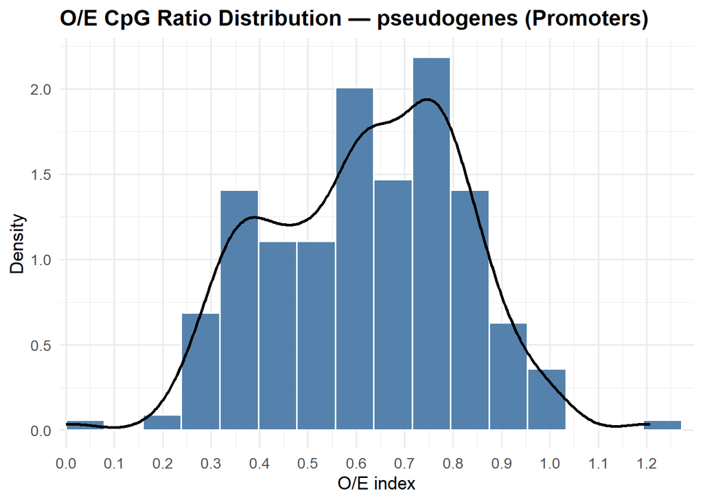

```r
x <- OE_all_promoters$OEindex
x <- x[is.finite(x)]
bw <- 2 * IQR(x) / length(x)^(1/3)
if (!is.finite(bw) || bw <= 0) bw <- diff(range(x)) / 80
xmin <- floor(min(x) * 10) / 10
xmax <- ceiling(max(x) * 10) / 10

ggplot(OE_all_promoters, aes(x = OEindex)) +
  geom_histogram(aes(y = after_stat(density)),
                 binwidth = bw, boundary = 0, closed = "left",
                 fill = "#4C7BA8", color = "white", alpha = 0.95) +
  geom_density(linewidth = 0.9, color = "black", alpha = 0.6) +
  scale_x_continuous(
    breaks = seq(xmin, xmax, by = 0.1),
    minor_breaks = seq(xmin, xmax, by = 0.05),
    labels = number_format(accuracy = 0.1),
    expand = expansion(mult = c(0.01, 0.02))
  ) +
  labs(
    title = "O/E CpG Ratio Distribution — pseudogenes (Promoters)",
    x = "O/E index",
    y = "Density"
  ) +
  theme_minimal(base_size = 13) +
  theme(
    panel.grid.minor = element_line(),
    plot.title = element_text(face = "bold")
  )
```

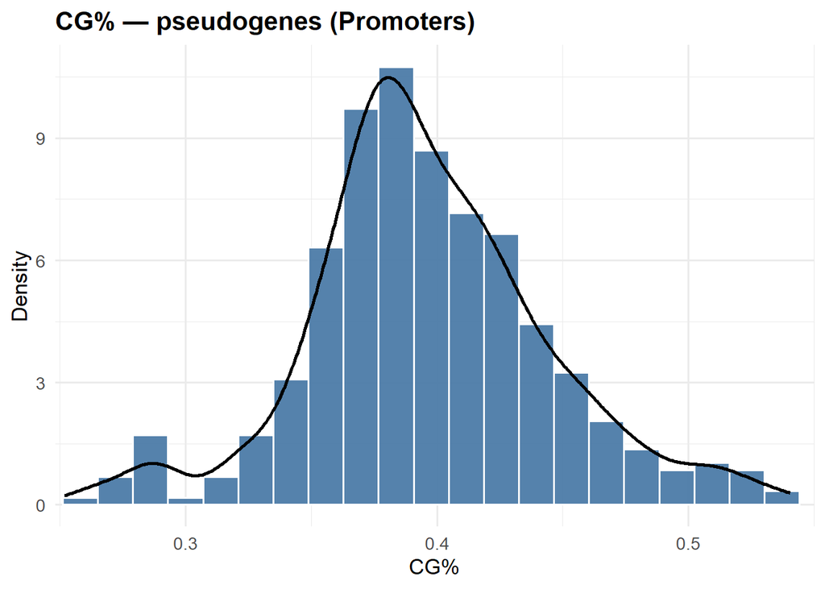

```r
x <- cgContent_all_promoters$CGpercentage
x <- x[is.finite(x)]
bw <- 2 * IQR(x) / length(x)^(1/3)
if (!is.finite(bw) || bw <= 0) bw <- diff(range(x)) / 80
xmin <- floor(min(x) * 10) / 10
xmax <- ceiling(max(x) * 10) / 10

ggplot(cgContent_all_promoters, aes(x = CGpercentage)) +
  geom_histogram(aes(y = after_stat(density)),
                 binwidth = bw, boundary = 0, closed = "left",
                 fill = "#4C7BA8", color = "white", alpha = 0.95) +
  geom_density(linewidth = 0.9, color = "black", alpha = 0.6) +
  scale_x_continuous(
    breaks = seq(xmin, xmax, by = 0.1),
    minor_breaks = seq(xmin, xmax, by = 0.05),
    labels = number_format(accuracy = 0.1),
    expand = expansion(mult = c(0.01, 0.02))
  ) +
  labs(
    title = "CG% — pseudogenes (Promoters)",
    x = "CG%",
    y = "Density"
  ) +
  theme_minimal(base_size = 13) +
  theme(
    panel.grid.minor = element_line(),
    plot.title = element_text(face = "bold")
  )
```

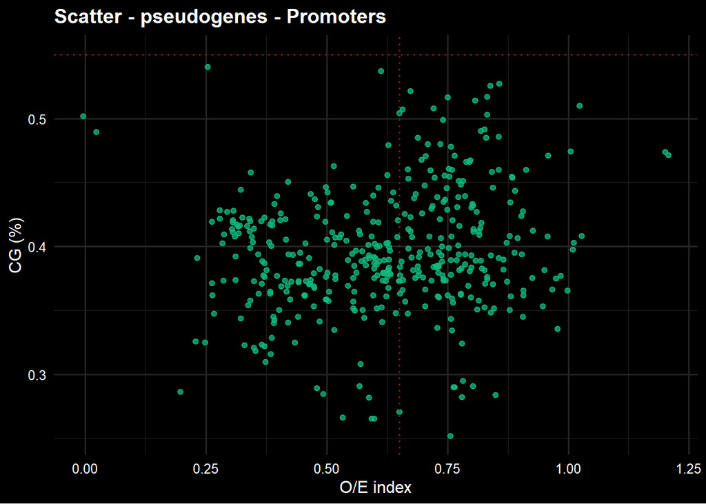

```r
plot_nice_dark <- function(d, x="OEindex", y="CGpercentage",
                           xthr=.65, ythr=.55, title="Scatter - pseudogenes - Promoters",
                           point_col="#10b981", thr_col="#7f1d1d"){   # green, violet
  dd <- data.frame(x=as.numeric(d[[x]]), y=as.numeric(d[[y]]))
  dd <- dd[is.finite(dd$x) & is.finite(dd$y), ]
  ggplot(dd, aes(x, y)) +
    geom_point(color=point_col, alpha=.75, size=1.6,
               position=position_jitter(width=.004, height=0)) +
    geom_vline(xintercept=xthr, color=thr_col, linewidth=.6, linetype="dotted") +
    geom_hline(yintercept=ythr, color=thr_col, linewidth=.6, linetype="dotted") +
    labs(title=title, x="O/E index", y="CG (%)") +
    theme_minimal(base_size=12) +
    theme(
      plot.background  = element_rect(fill="black", color=NA),
      panel.background = element_rect(fill="black", color=NA),
      panel.grid       = element_line(color="#242424"),
      axis.text        = element_text(color="white"),
      axis.title       = element_text(color="white"),
      plot.title       = element_text(color="white", face="bold")
    )
}

# use:
plot_nice_dark(df_promoters)
```

**PCA**

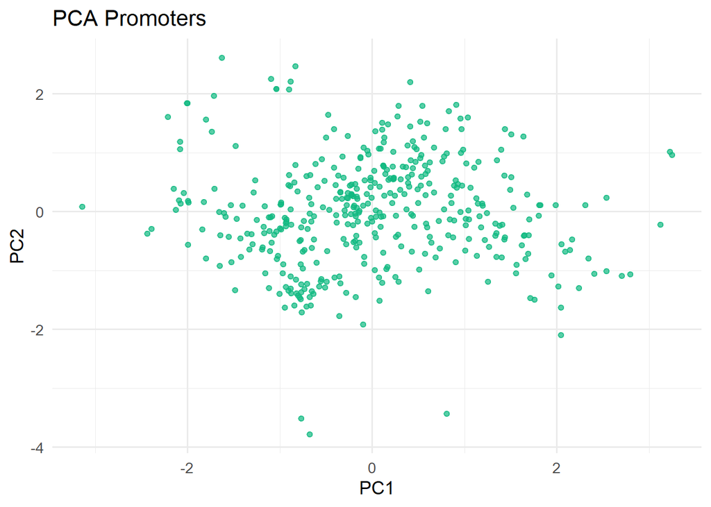

```r
# 1) Clean: keep numeric cols, drop NA/Inf rows, drop zero-variance cols
X <- df_promoters[, sapply(df_promoters, is.numeric), drop = FALSE]
X <- X[Reduce(`&`, lapply(X, is.finite)), , drop = FALSE]
X <- X[, sapply(X, function(z) sd(z) > 0), drop = FALSE]

# 2) PCA
pca <- prcomp(X, center = TRUE, scale. = TRUE)
pc  <- as.data.frame(pca$x[, 1:2, drop = FALSE])

ggplot(pc, aes(PC1, PC2)) +
  geom_point(alpha = .7, size = 1.6, color = "#10b981") +
  theme_minimal(base_size = 13) +
  labs(title = "PCA Promoters", x = "PC1", y = "PC2")
```

```r
summary(pca)
```

## Importance of components:

## PC1 PC2

## Standard deviation 1.0747 0.9192

## Proportion of Variance 0.5775 0.4225

## Cumulative Proportion 0.5775 1.0000

```r
cor(df$OEindex, df$CGpercentage)
```

## [1] 0.1337212

**K-Means**

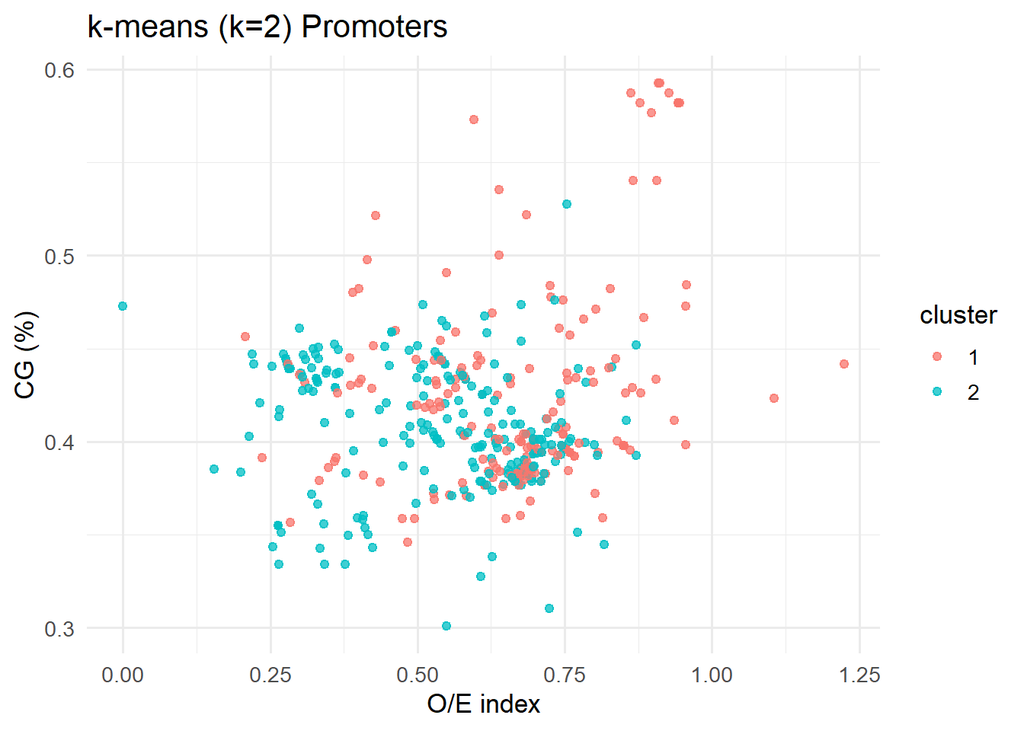

```r
# clean once; keep the mask so we can put labels back correctly
X <- df_promoters[, c("OEindex","CGpercentage")]
m <- is.finite(X$OEindex) & is.finite(X$CGpercentage)
Xc <- scale(X[m, , drop=FALSE])

set.seed(42)
k  <- 2
km <- kmeans(Xc, centers=k, nstart=50)

df$cluster <- NA_integer_
df$cluster[m] <- km$cluster
df$cluster <- factor(df$cluster)

ggplot(df[!is.na(df$cluster),], aes(OEindex, CGpercentage, color=cluster)) +
  geom_point(alpha=.75, size=1.7) +
  theme_minimal(base_size=13) +
  labs(title=sprintf("k-means (k=%d) Promoters", k),
       x="O/E index", y="CG (%)")
```

```r
#Add names
df_promoters <- cbind(geneinfo, df_promoters)
df_promoters
```

## DataFrame with 420 rows and 4 columns

## geneID Note OEindex CGpercentage

## 1 LOC_00005679 function unknown 0.380563 0.3160

## 2 LOC_00005727 function unknown 0.877897 0.4345

## 3 LOC_00005745 function unknown 0.275710 0.4285

## 4 LOC_00005857 function unknown 0.757695 0.3560

## 5 LOC_00006089 function unknown 0.843471 0.3930

## … … … … …

## 416 LOC_00000844 function unknown 0.955851 0.4710

## 417 LOC_00000852 function unknown 0.483499 0.4235

## 418 LOC_00000878 function unknown 0.284133 0.4025

## 419 LOC_00000917 function unknown 0.754067 0.3990

## 420 LOC_00000930 function unknown 0.627175 0.3675

```r
#Promoters list with cgi arquitecture
df_filtered_cgi_promoters <- dplyr::filter(as.data.frame(df_promoters), OEindex >= 0.65, CGpercentage >= .55)
df_filtered_cgi_promoters
```

| geneID | Note | OEindex | CGpercentage |
| --- | --- | --- | --- |

**Promoters Sum Count**

```r
C_all_sum_promoters <- sum(C_all_promoters)
G_all_sum_promoters <- sum(G_all_promoters)
Width_all_sum_promoters <- sum(width(seqs_promotores_500bp))
CG_all_sum_promoters <- sum(CG_all_promoters)
```

```r
C_all_sum_promoters <- as.numeric(C_all_sum_promoters)
G_all_sum_promoters  <- as.numeric(G_all_sum_promoters)
Width_all_sum_promoters <- as.numeric(Width_all_sum_promoters)
CG_all_sum_promoters <- as.numeric(CG_all_sum_promoters)
```

```r
C_all_sum_promoters
```

## [1] 164817

```r
G_all_sum_promoters
```

## [1] 168076

```r
Width_all_sum_promoters
```

## [1] 840000

```r
CG_all_sum_promoters
```

## [1] 20724

```r
#CG% sum - Body
cgContent_all_sum_promoters <- (C_all_sum_promoters+G_all_sum_promoters)/Width_all_sum_promoters
cgContent_all_sum_promoters
```

## [1] 0.3963012

```r
#OE Index sum - Body
OE_all_sum_promoters <- (CG_all_sum_promoters*Width_all_sum_promoters)/(C_all_sum_promoters*G_all_sum_promoters)
OE_all_sum_promoters
```

## [1] 0.628413

```r
#Body sums totals
C_all_sum_promoters
```

## [1] 164817

```r
G_all_sum_promoters
```

## [1] 168076

```r
Width_all_sum_promoters
```

## [1] 840000

```r
CG_all_sum_promoters
```

## [1] 20724

```r
cgContent_all_sum_promoters
```

## [1] 0.3963012

```r
OE_all_sum_promoters
```

## [1] 0.628413

```r
#Porcentaje/Ratio de GCs en el cuerpo segun el span del promoters
CG_all_sum_promoters/Width_all_sum_promoters
```

## [1] 0.02467143

```r
#Porcentaje/Ratio de GC del cuerpo en comparacion al genoma
genomeCG_totalcount = 45535149
CG_all_sum_promoters/45535149
```

## [1] 0.0004551209